# Definition der Objekte

Die bisherige Objektdefinition ist leider ziemlich instabil. Deshalb hier ein neuer Versuch.

```python
import sys
import numpy as np
import pandas as pd
import xarray as xr

import glob
import matplotlib.pyplot as plt
%matplotlib inline

from plotting_tools.colormaps import enhanced_colormap2
emap = enhanced_colormap2()

sys.path.append("/vols/talos/home/stephan/utils/tracking/")
import object_tracking as ot
import tracking_common as tc
```

```python
talos_home = "/vols/talos/home/stephan"
data_path = "{talos_home}/data".format(talos_home=talos_home)
track_data_path = "{dp}/radar_track/trackdata".format(dp=data_path)
```

Als nächstes lesen wir die Pfade aller möglichen manuellen Tracks ein und laden uns ein Beispiel.

```python
track_paths = glob.glob("{tdp}/*.nc".format(tdp=track_data_path))
```

```python
track_example = xr.open_dataset(track_paths[55])
```

```
<xarray.plot.facetgrid.FacetGrid at 0x7f19761fea50>
```

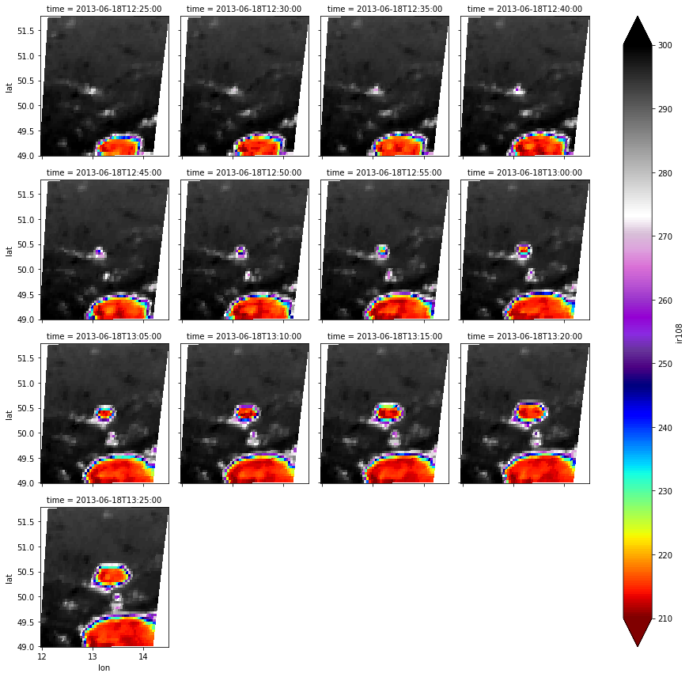

```python
track_example.ir108.plot(x='lon',y='lat',col='time',col_wrap=4,cmap=emap,vmin=210,vmax=300)
```

## Filter und Watershed

Eine Möglichkeit wäre auch eine Kombination aus Wolkenmase, Maximumfilter, um die lokalen Maxima zu finden und diese dann als ein Anfangspunkt für eine Watershedsegmentierung zu benutzen.

Dafür benötigen wir noch ein paar Pakete.

```python
from scipy import ndimage as ndi
from skimage.feature import peak_local_max
from skimage.morphology import watershed
from skimage.measure import regionprops
```

Dann suchen wir uns den CI-Zeitschritt aus.

```python
it = 6
```

Und wählen nur die wolkigen Bereiche aus.

```python
cloudy = np.ma.masked_where(track_example.cma[it]<2,track_example.ir108[it])
```

Dann glätten wir den Auschnitt mit einem Extremwertfilter, um dann die Extrema zu suchen.

```python
cloudy_max = ndi.maximum_filter(np.max(cloudy)-cloudy,5)
```

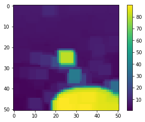

```python
plt.imshow(cloudy_max)
plt.colorbar()
```

```python
max_coordinates = peak_local_max(-cloudy,min_distance=3)
```

Da sollten wir mal einen Blick darauf werfen.

```
Text(0.5,1,u'IR 10,8 \xb5m, mit lokalen Minima\n2013-06-18 12:55:00 UTC')
```

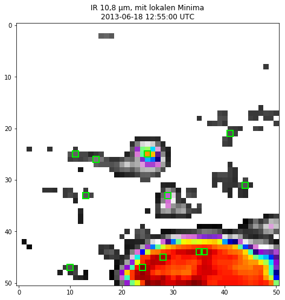

```python
fig,ax = plt.subplots(1,1,figsize=(8,8))
ax.imshow(cloudy,vmin=210,vmax=300,cmap=emap)

for p in max_coordinates:
    ax.plot(p[1],p[0],markersize=10,mew=2,color='#00ee00',marker='s',markerfacecolor='none')

ax.set_title(u"IR 10,8 µm, mit lokalen Minima\n{} UTC".format(pd.to_datetime(str(track_example.time[it].data)).replace(tzinfo=None)))
```

Als nächstes erstellen wir eine neue Matrix mit den lokalen Minima, um sie für die Wateshedsegmentierung als Startpunkte zu benutzen.

```python
markers = np.zeros_like(track_example.ir108[it])
```

```python
for i,p in enumerate(max_coordinates):
    markers[p[0],p[1]] = i+1
```

```
Text(0.5,1,u'Markierungen\n2013-06-18 12:55:00 UTC')
```

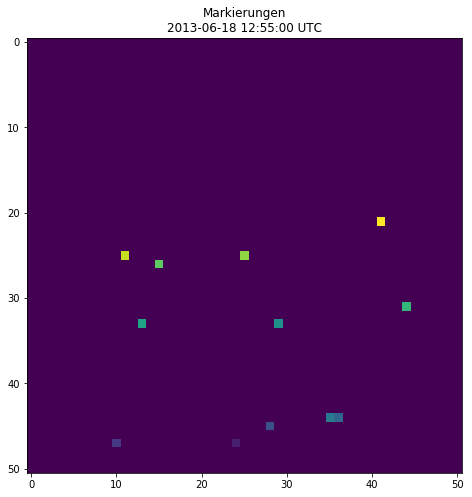

```python
fig,ax = plt.subplots(1,1,figsize=(8,8))
ax.imshow(markers)

ax.set_title(u"Markierungen\n{} UTC".format(pd.to_datetime(str(track_example.time[it].data)).replace(tzinfo=None)))
```

Dann können wir die Segmentierung durchführen und uns ansehen.

```python
labels = watershed(cloudy, markers, mask=~cloudy.mask)
```

```
Text(0.5,1,u'segmentierter IR 10,8 \xb5m\n2013-06-18 12:55:00 UTC')
```

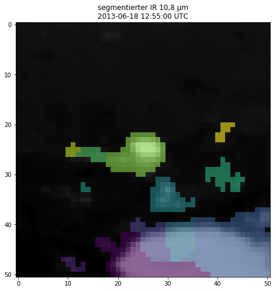

```python
fig,ax = plt.subplots(1,1,figsize=(8,8))
ax.imshow(track_example.ir108[7].data,vmin=210,vmax=300,cmap='gray_r')
ax.imshow(np.ma.masked_less(labels,1),alpha=0.6)
ax.set_title(u"segmentierter IR 10,8 µm\n{} UTC".format(pd.to_datetime(str(track_example.time[it].data)).replace(tzinfo=None)))
```

Das scheint soweit vernünftig zu funktionieren. Allerdings werden Wolkenbereiche, die wahrscheinlich zu einem Objekt gehören, getrennt. Da sollte eine Glättung des Eingangsfeldes weiterhelfen. Eine Möglichkeit ist der bilaterale Filter, da er es ermöglicht, die Intensität und die Rauminformation getrennt zu glätten. Da wir die Intensität gerne stärker gelättet haben wollen als, die Rauminformationen, um die Segmentierung stabiler zu gestalten, setzten wir die Glättung für die Intensitöt auf einen sehr hohen Wert und versuchen die räumliche Glättung ganz wegzulassen.

Dafür benötigen wir allerdings noch das Paket cv2.

```python
import cv2
```

```python
neighbourhood = np.arange(5,50,5)
colour_smoothing = np.arange(25,250,25)
```

```python
smoothed_ir = {n:{c:{} for c in colour_smoothing} for n in neighbourhood}
```

```python
for n in neighbourhood:
    for c in colour_smoothing:
        smoothed_ir[n][c] = cv2.bilateralFilter(cloudy.astype("float32"),n,c,1)
```

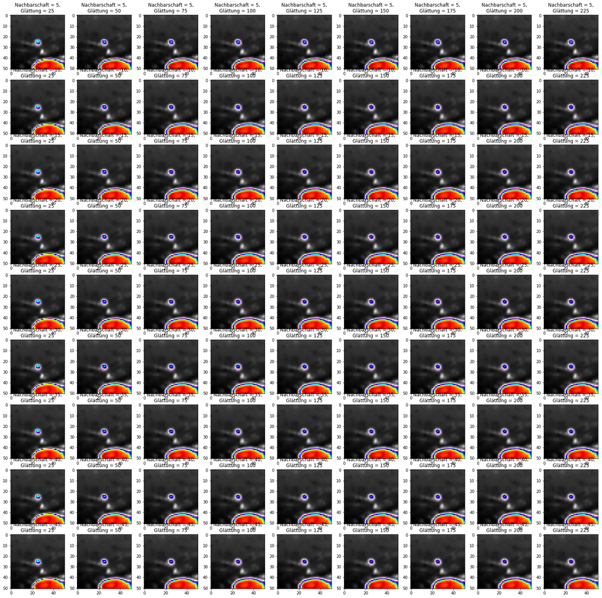

```python
i = 0
fig,ax = plt.subplots(len(neighbourhood),
                      len(colour_smoothing),
                      figsize=(len(neighbourhood)*3,
                               len(colour_smoothing)*3))
axs=ax.ravel()

for n in neighbourhood:
    for c in colour_smoothing:
        axs[i].imshow(smoothed_ir[n][c],vmin=210,vmax=300,cmap=emap)
        axs[i].set_title(u"Nachbarschaft = {n},\nGlättung = {g}".format(n=n,g=c))

        i +=1
```

Das sieht ganz so aus, als wären die Unterschiede ab einer Nachbarschaft von 20 und einer Glättung von 50 nicht mehr besonders groß. Also nehmen wir erstmal diese Werte.

```python
ir108_segmented = []

for i,ir in enumerate(track_example.ir108.data):
    ir = cv2.bilateralFilter(ir.astype("float32"),20,50,1)
    ir_masked = np.ma.masked_where(track_example.cma[i].data<2,ir)
    max_coordinates = peak_local_max(-ir_masked,min_distance=4)
    markers = np.zeros_like(ir_masked)

    for j,p in enumerate(max_coordinates):
        markers[p[0],p[1]] = j+1

    labels = watershed(ir_masked, markers, mask=~ir_masked.mask)

    ir108_segmented.append(labels)
```

Dann sehen wir uns das Ergebnis mal an.

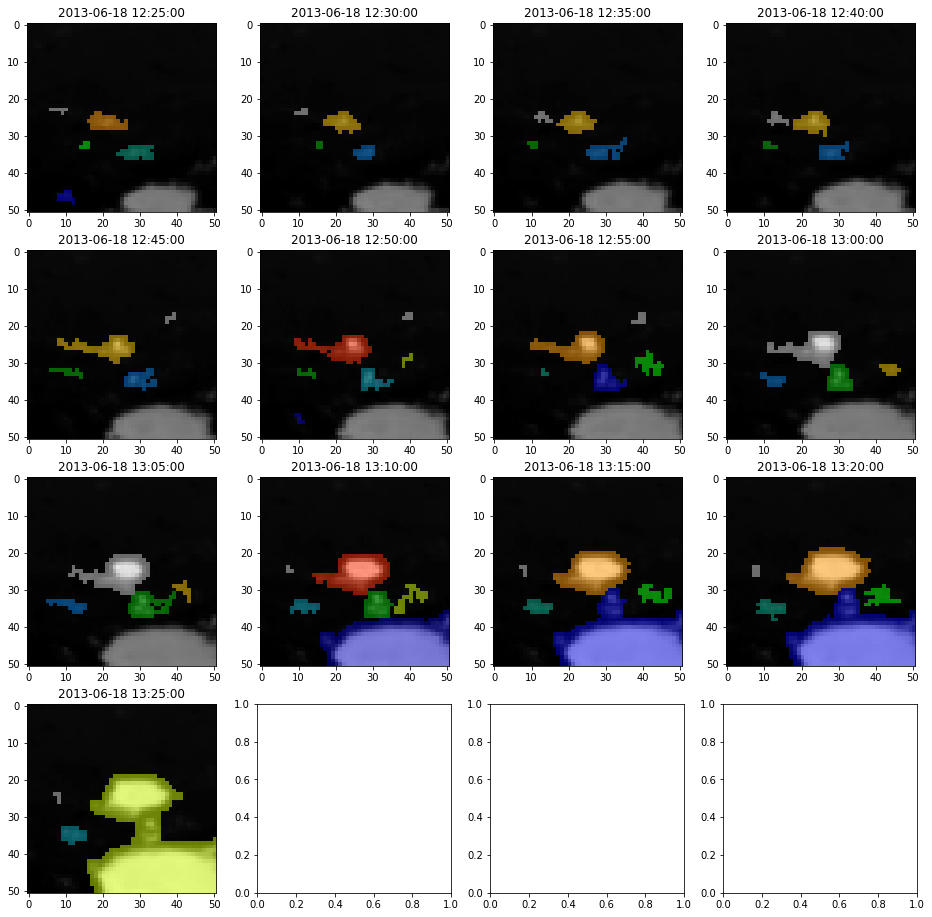

```python
fig,ax = plt.subplots(4,4,figsize=(16,16))
axs=ax.ravel()

for i,ir in enumerate(ir108_segmented):
    axs[i].imshow(track_example.ir108[i].data,vmin=210,vmax=300, cmap='gray_r')
    axs[i].imshow(np.ma.masked_less(ir,0),alpha=0.5,cmap='nipy_spectral')
    axs[i].set_title(pd.to_datetime(str(track_example.time[i].data)).replace(tzinfo=None))
```

Das sieht ziemlich gut aus. Es ist möglich die Wolken im ersten Zeitschritt gut zu trennen und erst im letzten Zeitschritt verschmelzen die meisten Wolken zu einem Objekt.

## Segmentierung des HRV-Kanals

Jetzt versuchen wir das Ganze noch einmal mit dem HRV-Kanal und hoffen, dass es auch für ihn funktioniert.

```python
from analysis_tools import make_hrv_upscaling as mhu

cma_h = np.array([mhu.make_hrv_upscaling(c) for c in track_example.cma.data])
```

```python
hrv_segmented = []

for i,h in enumerate(track_example.hrv.data):
    h = cv2.bilateralFilter(h.astype("float32"),15,25,1)
    h_masked = np.ma.masked_where(cma_h[i]<2,h)
    max_coordinates = peak_local_max(h_masked,min_distance=4)

    markers = np.zeros_like(h_masked)

    for j,p in enumerate(max_coordinates):
        markers[p[0],p[1]] = j+1

    labels = watershed(h_masked, markers, mask=~h_masked.mask)

    hrv_segmented.append(labels)
```

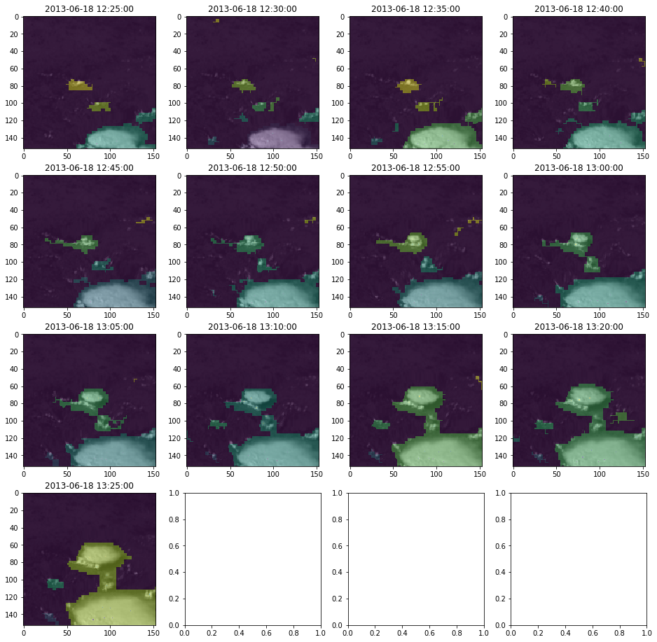

```python
fig,ax = plt.subplots(4,4,figsize=(16,16))
axs=ax.ravel()

for i,h in enumerate(hrv_segmented):
    axs[i].imshow(np.clip(track_example.hrv[i].data,0,1),vmin=0,vmax=1, cmap='gray')
    axs[i].imshow(np.ma.masked_less(h,0),alpha=0.4)
    axs[i].set_title(pd.to_datetime(str(track_example.time[i].data)).replace(tzinfo=None))
```

Das funktioniert auch, aber die grobe Auflösung der Wolkenmaske macht Probleme. Vielleicht ist der Reflektanzwert von 0,2 oder 0,3, wie in der CI-Evaluierung, besser geeignet.

```python
hrv_segmented = []

for i,h in enumerate(track_example.hrv.data):
    h = cv2.bilateralFilter(h.astype("float32"),15,25,1)
    h_masked = np.ma.masked_less(h,0.2)
    max_coordinates = peak_local_max(h_masked,min_distance=4)

    markers = np.zeros_like(h_masked)

    for j,p in enumerate(max_coordinates):
        markers[p[0],p[1]] = j+1

    labels = watershed(h_masked, markers, mask=~h_masked.mask)

    hrv_segmented.append(labels)
```

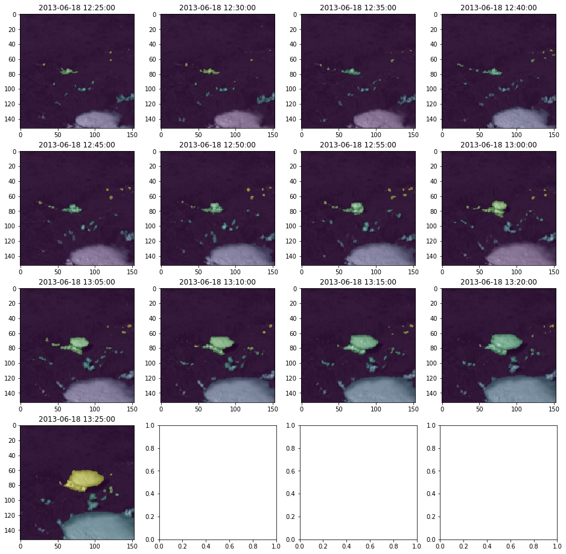

```python
fig,ax = plt.subplots(4,4,figsize=(16,16))
axs=ax.ravel()

for i,h in enumerate(hrv_segmented):
    axs[i].imshow(np.clip(track_example.hrv[i].data,0,1),vmin=0,vmax=1, cmap='gray')
    axs[i].imshow(np.ma.masked_less(h,0),alpha=0.4)
    axs[i].set_title(pd.to_datetime(str(track_example.time[i].data)).replace(tzinfo=None))
```

Das sieht deutlich besser aus und erlaubt eine viel bessere Trennung der Wolken als die Segmentierung des IR-10,8-µm-Kanals.

## Eigenschaften zum CI-Zeitpunkt

Es wäre vielleicht interessant zu sehen, wie sich die Objekteigenschaften zum CI-Zeipunkt verhalten. Dazu müssen wir erstmal das richtige Objekt finden. Das sollte zum CI-Zeitpunkt den Ausschnittsmittelpunkt beinhalten.

```python
mittelpunkt_hrv = (hrv_segmented[6].shape[0]//2,hrv_segmented[6].shape[1]//2)
```

```python
mittelpunkt_ir108 = (ir108_segmented[6].shape[0]//2,ir108_segmented[6].shape[1]//2)
```

```python
labels_hrv = np.unique(hrv_segmented[6])
```

```python
labels_ir108 = np.unique(ir108_segmented[6])
```

```python
wanted_object_hrv = []

for l in labels_hrv[1:]:
    points = np.where(hrv_segmented[6]==l)

    if mittelpunkt_hrv[0] in points[0] and mittelpunkt_hrv[1] in points[1]:
        wanted_object_hrv = l
```

```python
wanted_object_ir108 = []

for l in labels_ir108[1:]:
    points = np.where(ir108_segmented[6]==l)

    if mittelpunkt_ir108[0] in points[0] and mittelpunkt_ir108[1] in points[1]:
        wanted_object_ir108 = l
```

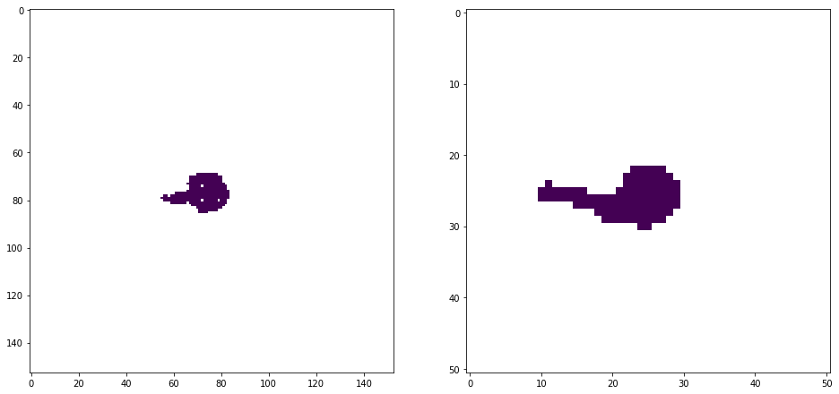

```python
fig,ax = plt.subplots(1,2,figsize=(16,10))
ax[0].imshow(np.ma.masked_not_equal(hrv_segmented[6],wanted_object_hrv))
ax[1].imshow(np.ma.masked_not_equal(ir108_segmented[6],wanted_object_ir108))
```